# Stat20 0823

## Introduction

- Prof. Stoyanov’s Lectures: TuTh 9:30-11 AM, 2050 Valley Life Sciences Bldg
- GSI : Lei Zhang
- Email: lei_zhang@berkeley.edu
- Office Hour:
- Books: Statistics (fourth edition) by Freedman, Pisani and Purves
- Software: R and R Studio for statistical analysis
- Homework:
- Quiz: biweekly with the first quiz on September 6
- You are not getting graded on the attendance

## Download R and RStudio

### Mac Users

To Install R

1. Open an internet browser and go to https://cran.cnr.berkeley.edu/.
2. Click on the “Download R for (Mac) OS X” link at the top of the page.
3. Click on the file containing the latest version of R
4. Save the .pkg file, double-click it to open, and follow the installation instructions

Now that R is installed, you need to download and install RStudio.

To Install RStudio

1. Go to www.rstudio.com and click on the “Download RStudio” button.
2. Click on “Download RStudio Desktop.”
3. Click on the version recommended for your system, or the latest Mac version, save the .dmg file on your computer, double-click it to open, and then drag and drop it to your applications folder.

### Windows Users

To Install R:

1. Open an internet browser and go to https://cran.cnr.berkeley.edu/.
2. Click on the “Download R for Windows” link at the top of the page.
3. Click on “install R for the first time.”
4. Click on “Download R 3.5.1 for Windows”
5. Click “Download R for Windows” and save the executable file somewhere on your computer.
6. Run the .exe file and follow the installation instructions.

Now that R is installed, you need to download and install RStudio.

To Install RStudio,

1. Go to www.rstudio.com and click on the “Download RStudio” button.
2. Click on “Download RStudio Desktop.”
3. Click on the version recommended for your system, or the latest Windows version, and save the executable file.
4. Run the .exe file and follow the installation instructions.

## Download ggplot2

```r
install.packages("ggplot2")
```

After you download ggplot2, remeber to load it. A few examples of ggplot2.

```r
library(ggplot2)

data("midwest", package = "ggplot2")#load the data
head(midwest)#return the first part of data
```

```
## # A tibble: 6 x 28
##     PID county state  area poptotal popdensity popwhite popblack
##   <int> <chr>  <chr> <dbl>    <int>      <dbl>    <int>    <int>
## 1   561 ADAMS  IL    0.052    66090      1271.    63917     1702
## 2   562 ALEXA~ IL    0.014    10626       759      7054     3496
## 3   563 BOND   IL    0.022    14991       681.    14477      429
## 4   564 BOONE  IL    0.017    30806      1812.    29344      127
## 5   565 BROWN  IL    0.018     5836       324.     5264      547
## 6   566 BUREAU IL    0.05     35688       714.    35157       50
## # ... with 20 more variables: popamerindian <int>, popasian <int>,
## #   popother <int>, percwhite <dbl>, percblack <dbl>, percamerindan <dbl>,
## #   percasian <dbl>, percother <dbl>, popadults <int>, perchsd <dbl>,
## #   percollege <dbl>, percprof <dbl>, poppovertyknown <int>,
## #   percpovertyknown <dbl>, percbelowpoverty <dbl>,
## #   percchildbelowpovert <dbl>, percadultpoverty <dbl>,
## #   percelderlypoverty <dbl>, inmetro <int>, category <chr>
```

```r
tail(midwest)#return the last part of data
```

```
## # A tibble: 6 x 28
##     PID county state  area poptotal popdensity popwhite popblack
##   <int> <chr>  <chr> <dbl>    <int>      <dbl>    <int>    <int>
## 1  3047 WASHI~ WI    0.025    95328      3813.    94465      125
## 2  3048 WAUKE~ WI    0.034   304715      8962.   298313     1096
## 3  3049 WAUPA~ WI    0.045    46104      1025.    45695       22
## 4  3050 WAUSH~ WI    0.037    19385       524.    19094       29
## 5  3051 WINNE~ WI    0.035   140320      4009.   136822      697
## 6  3052 WOOD   WI    0.048    73605      1533.    72157       90
## # ... with 20 more variables: popamerindian <int>, popasian <int>,
## #   popother <int>, percwhite <dbl>, percblack <dbl>, percamerindan <dbl>,
## #   percasian <dbl>, percother <dbl>, popadults <int>, perchsd <dbl>,
## #   percollege <dbl>, percprof <dbl>, poppovertyknown <int>,
## #   percpovertyknown <dbl>, percbelowpoverty <dbl>,
## #   percchildbelowpovert <dbl>, percadultpoverty <dbl>,
## #   percelderlypoverty <dbl>, inmetro <int>, category <chr>
```

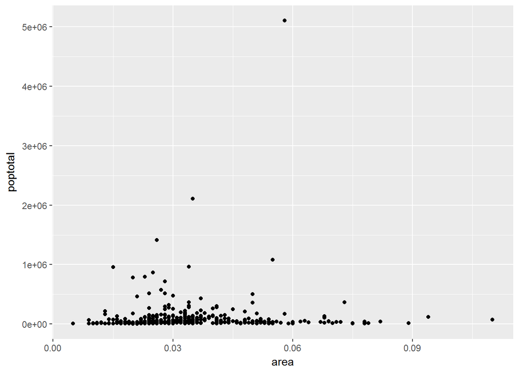

```r
#simple scatter plot
ggplot(midwest, aes(x=area, y=poptotal)) +
  geom_point()
```

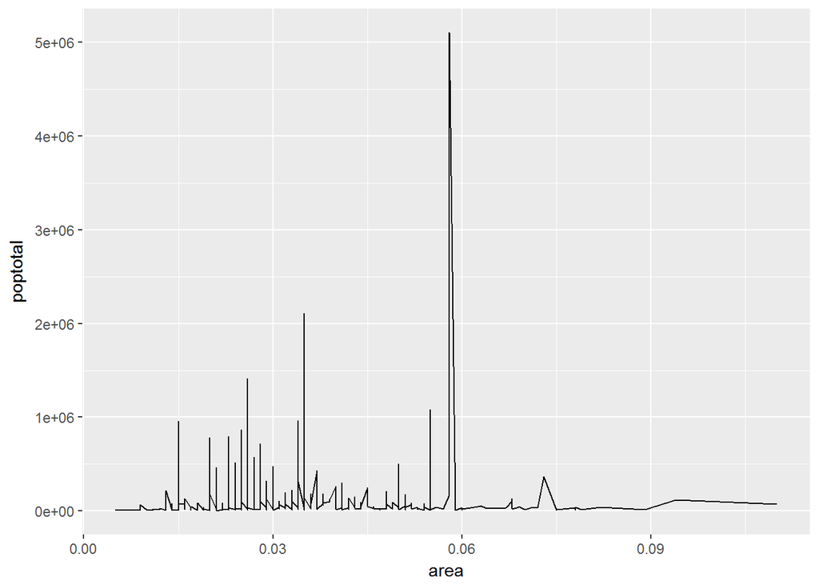

```r
#simple line plot
ggplot(midwest, aes(x=area, y=poptotal)) +
  geom_line()
```

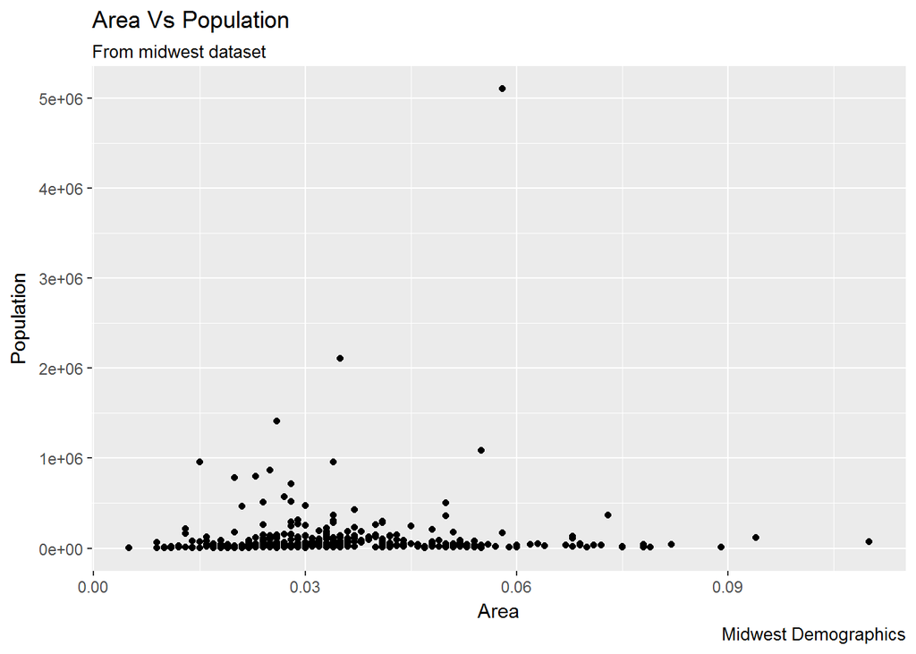

```r
#scatter plot iwth title
ggplot(midwest, aes(x=area, y=poptotal)) +
  geom_point() +
  labs(title="Area Vs Population", subtitle="From midwest dataset", y="Population", x="Area", caption="Midwest Demographics")
```

## References

- https://courses.edx.org/courses/UTAustinX/UT.7.01x/3T2014/56c5437b88fa43cf828bff5371c6a924/
- http://r-statistics.co/Complete-Ggplot2-Tutorial-Part1-With-R-Code.html